# Spooky stats tutorial

Jill Ashey

2025-10-28

## Spooky stats!

### Load libraries

## Data & metadata - reading in, joining, checking structure

Read in raw data. The raw data is exactly that - raw quantitative measurements.

```r
raw_data <- read.csv("data/coral_patch_seasons.csv")
head(raw_data)
```

```
##   coral_id growth_rate photosynthesis
## 1      A01        0.95            1.2
## 2      A02        0.99            1.0
## 3      A03        1.01            1.3
## 4      A04        0.81            1.1
## 5      A05        0.77            1.7
## 6      A06        0.85            1.8
```

```r
str(raw_data)
```

```
## 'data.frame':    24 obs. of  3 variables:
##  $ coral_id      : chr  "A01" "A02" "A03" "A04" ...
##  $ growth_rate   : num  0.95 0.99 1.01 0.81 0.77 0.85 1.1 1.13 1.15 0.98 ...
##  $ photosynthesis: num  1.2 1 1.3 1.1 1.7 1.8 2 2.7 2.2 2.1 ...
```

We have two continuous numerical variables in our dataframe - `growth_rate` and `photosynthesis` - for each coral ID.

Read in metadata. Metadata is “data about the data” and provides information that gives context to other data. It helps us understand and use the data correctly.

```r
metadata <- read.csv("data/coral_metadata.csv")
head(metadata)
```

```
##   coral_id season pumpkin_patch_nearby
## 1      A01 Spring                  Yes
## 2      A02 Spring                  Yes
## 3      A03 Spring                  Yes
## 4      A04 Spring                   No
## 5      A05 Spring                   No
## 6      A06 Spring                   No
```

```r
str(metadata)
```

```
## 'data.frame':    24 obs. of  3 variables:
##  $ coral_id            : chr  "A01" "A02" "A03" "A04" ...
##  $ season              : chr  "Spring" "Spring" "Spring" "Spring" ...
##  $ pumpkin_patch_nearby: chr  "Yes" "Yes" "Yes" "No" ...
```

We have two explanatory variables in our metadata - `season` (spring, summer, winter, fall) and `pumpkin_patch_nearby` (Yes or No).

Join dataframes so data and metadata are in one dataframe.

```r
joined_data <- left_join(raw_data, metadata, by = "coral_id")
head(joined_data)
```

```
##   coral_id growth_rate photosynthesis season pumpkin_patch_nearby
## 1      A01        0.95            1.2 Spring                  Yes
## 2      A02        0.99            1.0 Spring                  Yes
## 3      A03        1.01            1.3 Spring                  Yes
## 4      A04        0.81            1.1 Spring                   No
## 5      A05        0.77            1.7 Spring                   No
## 6      A06        0.85            1.8 Spring                   No
```

```r
str(joined_data)
```

```
## 'data.frame':    24 obs. of  5 variables:
##  $ coral_id            : chr  "A01" "A02" "A03" "A04" ...
##  $ growth_rate         : num  0.95 0.99 1.01 0.81 0.77 0.85 1.1 1.13 1.15 0.98 ...
##  $ photosynthesis      : num  1.2 1 1.3 1.1 1.7 1.8 2 2.7 2.2 2.1 ...
##  $ season              : chr  "Spring" "Spring" "Spring" "Spring" ...
##  $ pumpkin_patch_nearby: chr  "Yes" "Yes" "Yes" "No" ...
```

We will now explore how growth rate and photosynthesis varies by season and presence of a pumpkin patch using ANOVA (Analysis of Variance). ANOVA (Analysis of Variance) compares the average values (means) of groups to see if they differ significantly, considering multiple groups at once. We test two factors here: season and pumpkin patch presence, plus their interaction. The interaction tests if the effect of one factor depends on the other.

## Growth rate data analysis

### Assess normality

To use ANOVAs effectively, our data needs to meet the following assumptions:

- Data are normally distributed
- Variances of groups are homogenous
- Observations are independent

Assess growth rate normality

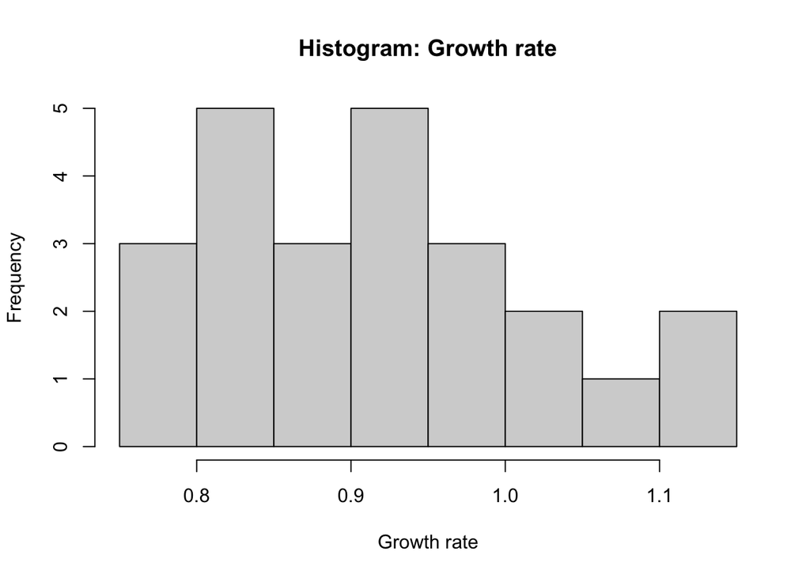

```r
# Visualize data with histogram and Q-Q plot
hist(joined_data$growth_rate, main="Histogram: Growth rate", xlab="Growth rate")
```

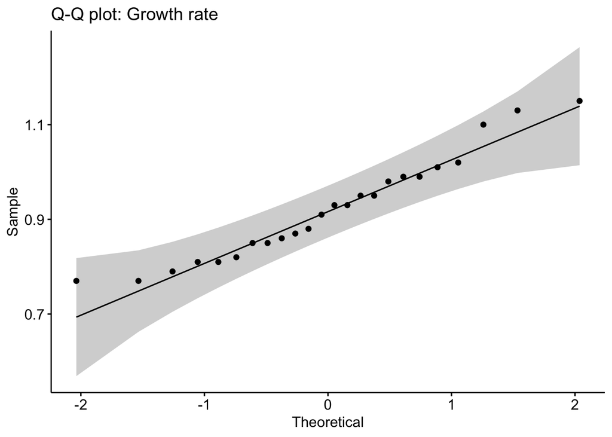

```r
ggqqplot(joined_data$growth_rate, title="Q-Q plot: Growth rate")
```

```r
# Shapiro-Wilk normality test
shapiro.test(joined_data$growth_rate)
```

```
##
##  Shapiro-Wilk normality test
##
## data:  joined_data$growth_rate
## W = 0.94802, p-value = 0.2454
```

```r
# Levene test of equal variance
leveneTest(growth_rate ~ interaction(season, pumpkin_patch_nearby), data = joined_data)
```

```
## Levene's Test for Homogeneity of Variance (center = median)
##       Df F value Pr(>F)
## group  7  0.2742 0.9552
##       16
```

Growth rate is normal and meets assumptions of ANOVA! What would we do if the data was NOT normal and/or did not meet ANOVA assumptions?

### Run ANOVA

Time to run ANOVA on our data!

```r
anova1 <- aov(growth_rate ~ pumpkin_patch_nearby * season, data=joined_data)
summary(anova1)
```

```
##                             Df  Sum Sq Mean Sq F value   Pr(>F)
## pumpkin_patch_nearby         1 0.12327 0.12327 130.326 4.22e-09 ***
## season                       3 0.13153 0.04384  46.355 4.09e-08 ***
## pumpkin_patch_nearby:season  3 0.00660 0.00220   2.326    0.113
## Residuals                   16 0.01513 0.00095
## ---
## Signif. codes:  0 '***' 0.001 '**' 0.01 '*' 0.05 '.' 0.1 ' ' 1
```

Let’s break down the ANOVA results table:

- Df = Degrees of freedom – represents how many pieces of information you have to estimate variability for that factor.
  - For each factor, df = number of groups - 1.
- Sum Sq = Sum of Squares – tells us how much total variability is explained by differences among groups vs. variation witin groups.
  - In our data, SS for pumpkin patch (0.12327) and season (0.13153) are relatively larger compared to the residual SS (0.01513). This means that a substantial portion of total variablity in growth rate is explained by differences in pumpkin patch groups and seasons.
- Mean Sq = Mean Square – represents the average amount of variation attributed to each source per degree of freedom (MS = SS / df). It essentially normalizes the sum of squares to degrees of freedom to estimate variances.
- F-value – ratio that compares variance between group means to the variance within groups (F = MS between groups / Residual MS).
  - The F-value serves as a “signal-to-noise” ratio: a high F-value indicates a strong signal (meaningful differences among groups), while a low F-value indicates mostly noise (no meaningful group differences).
  - For hypothesis testing, the F-value is compared to a critical value from the F-distribution (based on degrees of freedom). If the F-value exceeds this threshold, the null hypothesis that all group means are equal is rejected. This determines the Pr(>F).
- Pr(>F) – the p-value associated with the F-statistic. It tells us the probability of obtaining an F-value at least as extreme as the one calculated from our data.

What are the ANOVA results telling us statistically and biologically?

#### Residuals and evaluating residual normality

Residuals are the differences between observed values and their predicted group means. They indicate how much individual data points deviate from group averages after accounting for the factors in the model. Analyzing residuals helps check model fit and assumptions.

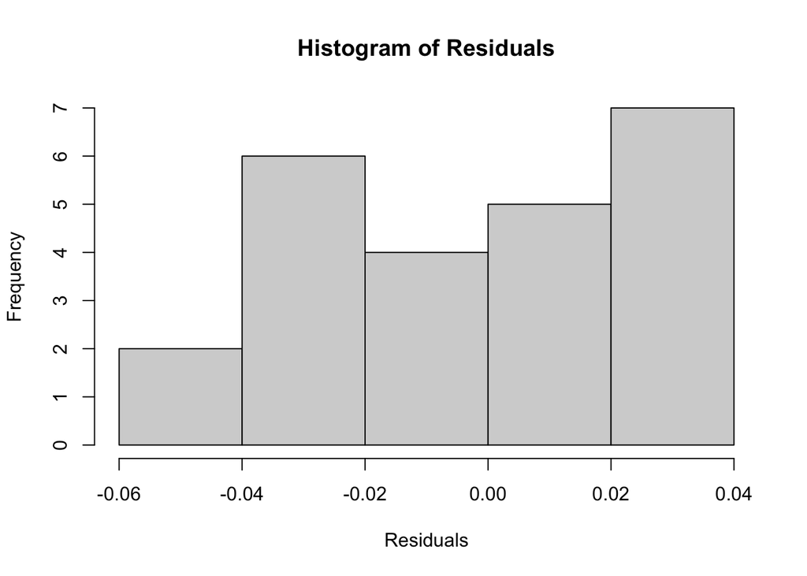

```r
# Extract residuals
residuals <- residuals(anova1)

# Histogram of residuals
hist(residuals, main = "Histogram of Residuals", xlab = "Residuals")
```

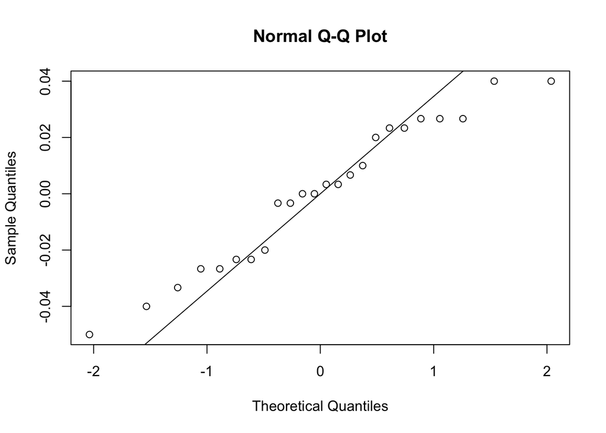

```r
# Q-Q Plot of residuals
qqnorm(residuals)
qqline(residuals)
```

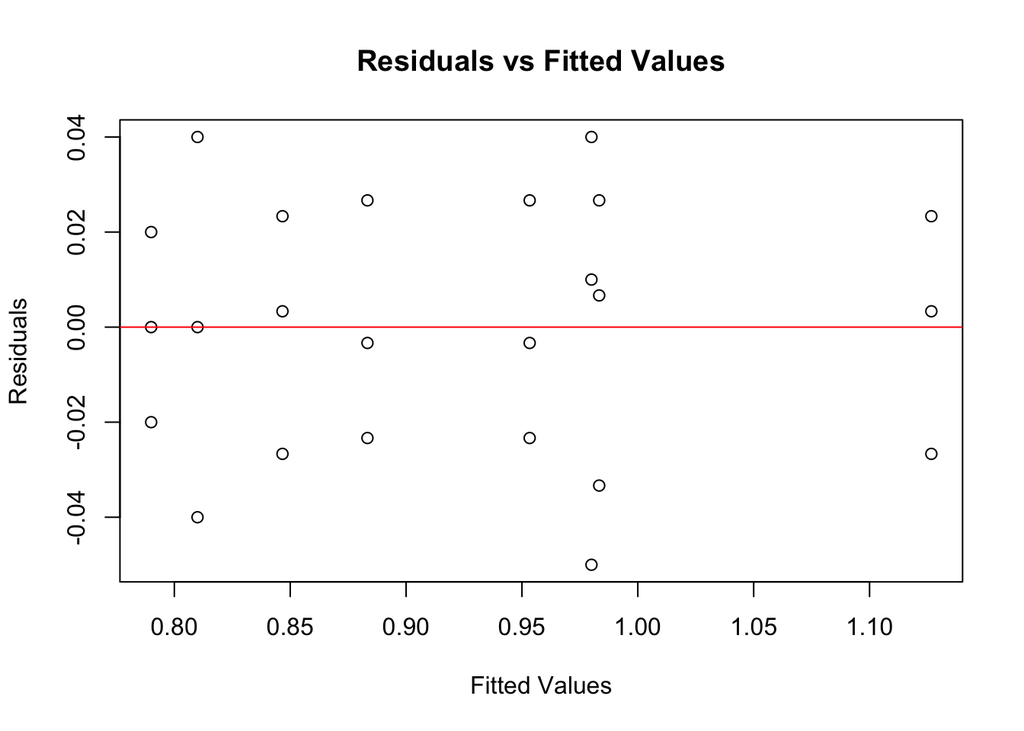

```r
# Residuals vs Fitted Values
plot(fitted(anova1), residuals,
xlab = "Fitted Values", ylab = "Residuals",
main = "Residuals vs Fitted Values")
abline(h = 0, col = "red")
```

Residuals also look normal, which means our model is a good fit for our data.

### Run post-hoc test

A post-hoc test is conducted after a significant ANOVA result to identify exactly which group means differ from each other. While ANOVA tells you there is at least one significant difference among groups, it does not specify which pairs of groups are different.

Here, we are using Tukey’s Honestly Significant Differences (HSD), which compares all possible pairs of group means, while controlling the error rate when testing multiple pairs

```r
TukeyHSD(anova1, which = "season")
```

```
##   Tukey multiple comparisons of means
##     95% family-wise confidence level
##
## Fit: aov(formula = growth_rate ~ pumpkin_patch_nearby * season, data = joined_data)
##
## $season
##                      diff         lwr          upr     p adj
## Spring-Fall   -0.01666667 -0.06746712  0.034133782 0.7848569
## Summer-Fall    0.12666667  0.07586622  0.177467115 0.0000129
## Winter-Fall   -0.07666667 -0.12746712 -0.025866218 0.0026841
## Summer-Spring  0.14333333  0.09253288  0.194133782 0.0000027
## Winter-Spring -0.06000000 -0.11080045 -0.009199551 0.0180375
## Winter-Summer -0.20333333 -0.25413378 -0.152532885 0.0000000
```

```r
TukeyHSD(anova1, which = "pumpkin_patch_nearby")
```

```
##   Tukey multiple comparisons of means
##     95% family-wise confidence level
##
## Fit: aov(formula = growth_rate ~ pumpkin_patch_nearby * season, data = joined_data)
##
## $pumpkin_patch_nearby
##             diff      lwr       upr p adj
## Yes-No 0.1433333 0.116717 0.1699497     0
```

```r
# What if the interaction term was significant?
#emm_interaction <- emmeans(anova1, ~ pumpkin_patch_nearby * season)
#pairs(emm_interaction, adjust = "tukey")
```

What are the post-hoc results telling us statistically and biologically?

### Visualize

Data visualization is a critical part of data analysis, as it is a visual representation of your data. It helps make complex findings easier to interpret and allows the audience to identify important patterns or trends.

Calculate means and standard errors for each group of `season` and `pumpkin_patch_nearby`.

```r
summary_data <- joined_data %>%
  group_by(season, pumpkin_patch_nearby) %>%
  summarise(
    mean_growth = mean(growth_rate, na.rm = TRUE),
    se_growth = sd(growth_rate, na.rm = TRUE) / sqrt(n()))
```

Plot means with standard error bars and connecting lines.

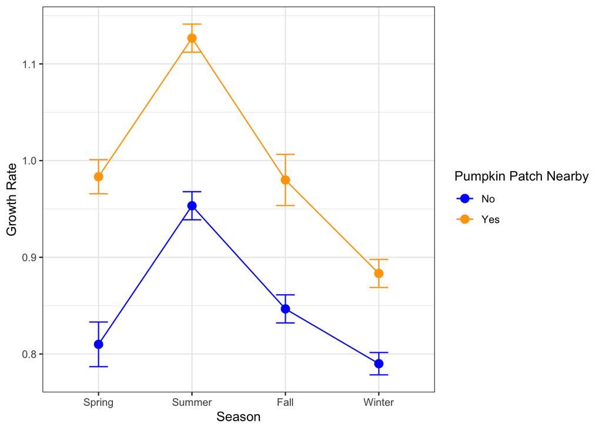

```r
# Order seasons
summary_data$season <- factor(summary_data$season, levels = c("Spring", "Summer", "Fall", "Winter"))

ggplot(summary_data, aes(x = season, y = mean_growth, color = pumpkin_patch_nearby, group = pumpkin_patch_nearby)) +
  geom_point(size = 3) +
  geom_line() +
  geom_errorbar(aes(ymin = mean_growth - se_growth, ymax = mean_growth + se_growth), width = 0.2) +
  scale_color_manual(values = c("Yes" = "orange", "No" = "blue")) +
  labs(x = "Season", y = "Growth Rate", color = "Pumpkin Patch Nearby") +
  theme_bw()
```

What are other ways we could use to visualize this data?

## Photosynthesis data analysis

### Assess normality

### Run ANOVA

### Run post-hoc test

### Visualize